# Analyzing Price and Graduation

# HW 3

### Which variables correlate with our outcome variable?

This is similar to the steps that we did above when checking for multicollinearity. In this case, we are taking all of our covariates, our predictor variable and our outcome variable and putting them into a correlation matrix. The goal is to identify variables that are significantly associated with the outcome variable. We will have two versions. The first will have all of the variables and the second will include only the variables that made it into the model. This means, that it will include only variables that are significantly correlated to the outcome variable AND are not highly correlated with another variable (r > 0.6).

It seems from below, graduation rate and total enrollment are highly correlated but we do not care about that. Aside from that, the table reports the same as our previous one, that Federal and State are highly related. Additionally, Total enrollment and Federal are highly related as well. Thus we will have to remove some of these variables to not violate the assumption of multicollinearity.

```r
# This time we will do it for all
exhaustive.continuous.predictors <- data %>%
  select(-c(HBCU,
            Tribal,
            Carnegie,
            Land.Grant,
            Institution.ID,
            Institution,
            Institution.Sector))

# dimensions of covariates
dim(exhaustive.continuous.predictors)
```

```
[1] 472  16
```

```r
# Remove any missing data in our covariates
exhaustive.continuous.predictors <- drop_na(exhaustive.continuous.predictors)

dim(exhaustive.continuous.predictors)
```

```
[1] 472  16
```

```r
# Data cleaning, have Graduation rate and Price as the first two variables in the dataframe
exhaustive.continuous.predictors <- exhaustive.continuous.predictors %>%
  select(Graduation.Rate, Price, everything())

# Run a correlation matrix, but it is difficult to see- so let's change it a bit
# 1. convert the correlation matrix into a data.frame
cor.df <- cor(exhaustive.continuous.predictors) %>%
  data.frame()

# 2. convert it to long then return only the correlations larger than .6 (Not including 1.00)
cor.df %>%
  mutate(variables = row.names(cor.df)) %>%
  pivot_longer(-variables) %>%
  filter(value > .6 & value != 1) %>%
  arrange(value) %>%
  mutate(value = round(value,2)) %>%
  kbl() %>%
  kable_paper(bootstrap_options = "striped", full_width = F)
```

| variables | name | value |
| --- | --- | --- |
| Graduation.Rate | Total.Enrollment | 0.61 |
| Total Enrollment | Graduation.Rate | 0.61 |
| Federal | State | 0.64 |
| State | Federal | 0.64 |
| Federal | Total.Enrollment | 0.68 |
| Total Enrollment | Federal | 0.68 |

### Creating a correlation Matrix - Part 2

```r
# Create a correlation matrix
correlation.matrix.df <- correlation_matrix(exhaustive.continuous.predictors) %>%
  data.frame()

# Reintroduce names to the correlation matrix dataframe
names(correlation.matrix.df) <- names(exhaustive.continuous.predictors)

# Print our APA correlation matrix
correlation.matrix.df %>%
  kbl(caption = "Correlation matrix of all continuous variables") %>%
  kable_classic(full_width = F, html_font = "Cambria") %>%
  footnote(general = c("*** indicates p <.001", "** indicates p <.01 ","* indicates p <.05 "))
```

Correlation matrix of all continuous variables

|  | Graduation.Rate | Price | Federal | State | American Indian(%) | Asian(%) | Hawaii(%) | Black(%) | Hispanic(%) | White(%) | Unknown Ethnicity(%) | Non-Resident(%) | Two or more race(%) | Women(%) | Total Enrollment | Admitted(%) |
| --- | --- | --- | --- | --- | --- | --- | --- | --- | --- | --- | --- | --- | --- | --- | --- | --- |
| Graduation.Rate | 1.000 | 0.535*** | 0.527*** | 0.388*** | -0.147** | 0.470*** | -0.096* | -0.395*** | 0.004 | 0.185*** | -0.105* | 0.402*** | 0.042 | -0.394*** | 0.607*** | -0.406*** |
| Price | 0.535*** | 1.000 | 0.305*** | 0.324*** | -0.237*** | 0.496*** | -0.144** | -0.154*** | 0.118* | -0.071 | 0.003 | 0.338*** | 0.031 | -0.211*** | 0.342*** | -0.224*** |
| Federal | 0.527*** | 0.305*** | 1.000 | 0.636*** | -0.051 | 0.446*** | -0.022 | -0.136** | -0.016 | -0.094* | -0.020 | 0.540*** | 0.077 | -0.198*** | 0.682*** | -0.406*** |
| State | 0.388*** | 0.324*** | 0.636*** | 1.000 | -0.048 | 0.317*** | -0.016 | -0.145** | 0.036 | -0.043 | -0.066 | 0.357*** | 0.083 | -0.155*** | 0.537*** | -0.200*** |
| American Indian(%) | -0.147** | -0.237*** | -0.051 | -0.048 | 1.000 | -0.097* | -0.005 | -0.083 | -0.049 | -0.106* | 0.002 | -0.104* | 0.129** | 0.040 | -0.119** | 0.069 |
| Asian(%) | 0.470*** | 0.496*** | 0.446*** | 0.317*** | -0.097* | 1.000 | -0.025 | -0.198*** | 0.304*** | -0.390*** | -0.066 | 0.508*** | 0.182*** | -0.200*** | 0.513*** | -0.383*** |
| Hawaii(%) | -0.096* | -0.144** | -0.022 | -0.016 | -0.005 | -0.025 | 1.000 | -0.042 | -0.040 | -0.114* | -0.028 | -0.052 | -0.008 | 0.010 | -0.048 | 0.002 |
| Black(%) | -0.395*** | -0.154*** | -0.136** | -0.145** | -0.083 | -0.198*** | -0.042 | 1.000 | -0.204*** | -0.561*** | -0.031 | -0.133** | -0.172*** | 0.295*** | -0.200*** | -0.070 |
| Hispanic(%) | 0.004 | 0.118* | -0.016 | 0.036 | -0.049 | 0.304*** | -0.040 | -0.204*** | 1.000 | -0.523*** | -0.093* | 0.013 | -0.048 | 0.020 | 0.201*** | -0.010 |
| White(%) | 0.185*** | -0.071 | -0.094* | -0.043 | -0.106* | -0.390*** | -0.114* | -0.561*** | -0.523*** | 1.000 | -0.030 | -0.182*** | -0.012 | -0.166*** | -0.153*** | 0.218*** |
| Unknown Ethnicity(%) | -0.105* | 0.003 | -0.020 | -0.066 | 0.002 | -0.066 | -0.028 | -0.031 | -0.093* | -0.030 | 1.000 | -0.099* | -0.090 | 0.044 | -0.119** | 0.005 |
| Non-Resident(%) | 0.402*** | 0.338*** | 0.540*** | 0.357*** | -0.104* | 0.508*** | -0.052 | -0.133** | 0.013 | -0.182*** | -0.099* | 1.000 | 0.034 | -0.272*** | 0.514*** | -0.327*** |
| Two or more race(%) | 0.042 | 0.031 | 0.077 | 0.083 | 0.129** | 0.182*** | -0.008 | -0.172*** | -0.048 | -0.012 | -0.090 | 0.034 | 1.000 | -0.022 | 0.046 | -0.018 |
| Women(%) | -0.394*** | -0.211*** | -0.198*** | -0.155*** | 0.040 | -0.200*** | 0.010 | 0.295*** | 0.020 | -0.166*** | 0.044 | -0.272*** | -0.022 | 1.000 | -0.195*** | 0.107* |
| Total Enrollment | 0.607*** | 0.342*** | 0.682*** | 0.537*** | -0.119** | 0.513*** | -0.048 | -0.200*** | 0.201*** | -0.153*** | -0.119** | 0.514*** | 0.046 | -0.195*** | 1.000 | -0.300*** |
| Admitted(%) | -0.406*** | -0.224*** | -0.406*** | -0.200*** | 0.069 | -0.383*** | 0.002 | -0.070 | -0.010 | 0.218*** | 0.005 | -0.327*** | -0.018 | 0.107* | -0.300*** | 1.000 |

Note:  
*** indicates p <.001  
** indicates p <.01  
* indicates p <.05

When looking at the correlation matrix above, what we are really interested is in identifying any variables that significantly correlated with our outcome variable. It seems that from our 15 variables (not including graduation rate) that function as a predictor/covariate, two of them were not significant. These are the variables Hispanic (%) and Two or More races (%)- so these will be removed. Additionally, from our table above that reports variables that are highly correlated with each other. We have issues with the following:

- State vs Federal
- Total Enrollment vs Federal

The correlates between graduation rate and these variables are: Federal (r = .527), State (r = .388), and Total Enrollment (r = .607). This means that Total Enrollment is more correlated with Graduation Rate than Federal is with Graduation Rate, thus Federal will be dropped. Since Federal gets dropped, State no longer has multicollinearity issues. Therefore, Total Enrollment and State will remain as variables.

In conclusion, the variables that will be removed are the following three: Hispanic (%), Two or More races (%), and Federal.

### Creating a correlation Matrix - Part 3

This correlation matrix showcases all of the variables that made it into our first multiple regression model.

```r
# First model predictors
first.model.predictors <- exhaustive.continuous.predictors %>%
  select(-c(`Hispanic(%)`, `Two or more race(%)`, Federal))

# Create a correlation matrix
correlation.matrix.df <- correlation_matrix(first.model.predictors) %>%
  data.frame()

# Need to rearrange the order or rows to show strength descending order
# Will have to get creative here
correlation.matrix.df.orderd <- correlation.matrix.df %>%
  mutate(order = as.numeric(gsub("\\D", "", Graduation.Rate.))) %>%
  arrange(desc(order)) %>%
  select(-order)


# Reintroduce names to the correlation matrix dataframe
names(correlation.matrix.df.orderd) <- names(first.model.predictors)

# Print our APA correlation matrix
correlation.matrix.df.orderd %>%
  kbl(caption = "Table 5: Correlation matrix of all continuous variables that were included in the first model") %>%
  kable_classic(full_width = F, html_font = "Cambria") %>%
  footnote(general = c("*** indicates p <.001", "** indicates p <.01 ","* indicates p <.05 "))
```

Table 5: Correlation matrix of all continuous variables that were included in the first model

|  | Graduation.Rate | Price | State | American Indian(%) | Asian(%) | Hawaii(%) | Black(%) | White(%) | Unknown Ethnicity(%) | Non-Resident(%) | Women(%) | Total Enrollment | Admitted(%) |
| --- | --- | --- | --- | --- | --- | --- | --- | --- | --- | --- | --- | --- | --- |
| Graduation.Rate | 1.000 | 0.535*** | 0.388*** | -0.147** | 0.470*** | -0.096* | -0.395*** | 0.185*** | -0.105* | 0.402*** | -0.394*** | 0.607*** | -0.406*** |
| Total Enrollment | 0.607*** | 0.342*** | 0.537*** | -0.119** | 0.513*** | -0.048 | -0.200*** | -0.153*** | -0.119** | 0.514*** | -0.195*** | 1.000 | -0.300*** |
| Price | 0.535*** | 1.000 | 0.324*** | -0.237*** | 0.496*** | -0.144** | -0.154*** | -0.071 | 0.003 | 0.338*** | -0.211*** | 0.342*** | -0.224*** |
| Asian(%) | 0.470*** | 0.496*** | 0.317*** | -0.097* | 1.000 | -0.025 | -0.198*** | -0.390*** | -0.066 | 0.508*** | -0.200*** | 0.513*** | -0.383*** |
| Admitted(%) | -0.406*** | -0.224*** | -0.200*** | 0.069 | -0.383*** | 0.002 | -0.070 | 0.218*** | 0.005 | -0.327*** | 0.107* | -0.300*** | 1.000 |
| Non-Resident(%) | 0.402*** | 0.338*** | 0.357*** | -0.104* | 0.508*** | -0.052 | -0.133** | -0.182*** | -0.099* | 1.000 | -0.272*** | 0.514*** | -0.327*** |
| Black(%) | -0.395*** | -0.154*** | -0.145** | -0.083 | -0.198*** | -0.042 | 1.000 | -0.561*** | -0.031 | -0.133** | 0.295*** | -0.200*** | -0.070 |
| Women(%) | -0.394*** | -0.211*** | -0.155*** | 0.040 | -0.200*** | 0.010 | 0.295*** | -0.166*** | 0.044 | -0.272*** | 1.000 | -0.195*** | 0.107* |
| State | 0.388*** | 0.324*** | 1.000 | -0.048 | 0.317*** | -0.016 | -0.145** | -0.043 | -0.066 | 0.357*** | -0.155*** | 0.537*** | -0.200*** |
| White(%) | 0.185*** | -0.071 | -0.043 | -0.106* | -0.390*** | -0.114* | -0.561*** | 1.000 | -0.030 | -0.182*** | -0.166*** | -0.153*** | 0.218*** |
| American Indian(%) | -0.147** | -0.237*** | -0.048 | 1.000 | -0.097* | -0.005 | -0.083 | -0.106* | 0.002 | -0.104* | 0.040 | -0.119** | 0.069 |
| Unknown Ethnicity(%) | -0.105* | 0.003 | -0.066 | 0.002 | -0.066 | -0.028 | -0.031 | -0.030 | 1.000 | -0.099* | 0.044 | -0.119** | 0.005 |
| Hawaii(%) | -0.096* | -0.144** | -0.016 | -0.005 | -0.025 | 1.000 | -0.042 | -0.114* | -0.028 | -0.052 | 0.010 | -0.048 | 0.002 |

Note:  
*** indicates p <.001  
** indicates p <.01  
* indicates p <.05

# HW 4

### Run model 1

The list of variables to be used in the model then are as follows:

- Graduation Rate (Outcome)
- Total Enrollment
- Price (Predictor)
- Asian %
- Admitted %
- Non-resident %
- Black %
- Women %
- State %
- White %
- American Indian %
- Unknown Ethnicity %
- Hawaii %
- HBCU
- Tribal
- Land Grant

We did not include Hispanic and Two or More Races and Federal were not used for the reasons in the previous section. We decided not to add Carnegie just because it complicates the model.

```r
# Run the multiple regression (first model)
model1 <- lm(Graduation.Rate~
             `Total Enrollment` +
              Price +
             `Asian(%)` +
             `Admitted(%)` +
             `Non-Resident(%)` +
             `Black(%)` +
             `Women(%)` +
             State +
             `White(%)` +
             `American Indian(%)` +
             `Unknown Ethnicity(%)` +
             `Hawaii(%)` +
             HBCU +
             Tribal +
             Land.Grant,
             data = data)


# summarize the model
summary(model1)
```

```
Call:
lm(formula = Graduation.Rate ~ `Total Enrollment` + Price + `Asian(%)` +
    `Admitted(%)` + `Non-Resident(%)` + `Black(%)` + `Women(%)` +
    State + `White(%)` + `American Indian(%)` + `Unknown Ethnicity(%)` +
    `Hawaii(%)` + HBCU + Tribal + Land.Grant, data = data)

Residuals:
    Min      1Q  Median      3Q     Max
-35.300  -5.562   0.313   6.009  22.733

Coefficients:
                              Estimate      Std. Error t value
(Intercept)             71.92168791376  13.87036955434   5.185
`Total Enrollment`       0.00044372493   0.00004282710  10.361
Price                    0.00096503317   0.00011328921   8.518
`Asian(%)`               0.35014486620   0.10675520696   3.280
`Admitted(%)`           -0.21527405984   0.02709028452  -7.947
`Non-Resident(%)`       -0.09698263266   0.12044492946  -0.805
`Black(%)`              -0.14558047528   0.04996307199  -2.914
`Women(%)`              -0.22173845023   0.04953825356  -4.476
State                   -0.00000002596   0.00000002276  -1.141
`White(%)`               0.21812998782   0.03116091315   7.000
`American Indian(%)`    -0.13947512448   0.14558364438  -0.958
`Unknown Ethnicity(%)`  -0.17867856887   0.10631937672  -1.681
`Hawaii(%)`             -0.03008217988   0.09624821930  -0.313
HBCU2                   -8.57348673609   3.43703953518  -2.494
Tribal2                -18.38042616771  12.04653149382  -1.526
Land.Grant2             -2.50781195003   1.42691616283  -1.758
                                   Pr(>|t|)
(Intercept)            0.000000324896276172 ***
`Total Enrollment`     < 0.0000000000000002 ***
Price                  0.000000000000000238 ***
`Asian(%)`                          0.00112 **
`Admitted(%)`          0.000000000000015163 ***
`Non-Resident(%)`                   0.42112
`Black(%)`                          0.00375 **
`Women(%)`             0.000009614937729520 ***
State                               0.25445
`White(%)`             0.000000000009195529 ***
`American Indian(%)`                0.33855
`Unknown Ethnicity(%)`              0.09353 .
`Hawaii(%)`                         0.75477
HBCU2                               0.01297 *
Tribal2                             0.12776
Land.Grant2                         0.07950 .
---
Signif. codes:  0 '***' 0.001 '**' 0.01 '*' 0.05 '.' 0.1 ' ' 1

Residual standard error: 8.978 on 456 degrees of freedom
Multiple R-squared:  0.6846,    Adjusted R-squared:  0.6742
F-statistic: 65.98 on 15 and 456 DF,  p-value: < 0.00000000000000022
```

### Converting model1 into a data frame

```r
# Convert our second model into a dataframe
model1.df <- broom::tidy(model1)

model1.df %>%
  kbl(caption = "Model 1: Uncleaned") %>%
  kable_classic(full_width = F, html_font = "Cambria")
```

Model 1: Uncleaned

| term | estimate | std.error | statistic | p.value |
| --- | --- | --- | --- | --- |
| (Intercept) | 71.9216879 | 13.8703696 | 5.1852755 | 0.0000003 |
| `Total Enrollment` | 0.0004437 | 0.0000428 | 10.3608457 | 0.0000000 |
| Price | 0.0009650 | 0.0001133 | 8.5183148 | 0.0000000 |
| `Asian(%)` | 0.3501449 | 0.1067552 | 3.2798856 | 0.0011181 |
| `Admitted(%)` | -0.2152741 | 0.0270903 | -7.9465411 | 0.0000000 |
| `Non-Resident(%)` | -0.0969826 | 0.1204449 | -0.8052031 | 0.4211221 |
| `Black(%)` | -0.1455805 | 0.0499631 | -2.9137615 | 0.0037466 |
| `Women(%)` | -0.2217385 | 0.0495383 | -4.4761055 | 0.0000096 |
| State | 0.0000000 | 0.0000000 | -1.1410506 | 0.2544478 |
| `White(%)` | 0.2181300 | 0.0311609 | 7.0001154 | 0.0000000 |
| `American Indian(%)` | -0.1394751 | 0.1455836 | -0.9580412 | 0.3385497 |
| `Unknown Ethnicity(%)` | -0.1786786 | 0.1063194 | -1.6805833 | 0.0935287 |
| `Hawaii(%)` | -0.0300822 | 0.0962482 | -0.3125479 | 0.7547670 |
| HBCU2 | -8.5734867 | 3.4370395 | -2.4944394 | 0.0129686 |
| Tribal2 | -18.3804262 | 12.0465315 | -1.5257858 | 0.1277565 |
| Land.Grant2 | -2.5078120 | 1.4269162 | -1.7575048 | 0.0795028 |

### Cleaning the model1 results a bit

Let’s make the output cleaner so it looks publishable. Right now it looks slopy with the names and the numerous decimal numbers present.

```r
# Renaming the variables
model1.df.renamed <- model1.df %>%
  rename(Model = term,
         `Unstandardized B` = estimate,
         `Coefficients Std. Error` = std.error,
         t = statistic,
         `Sig.` = p.value)

# Renaming the values of the first row
model1.df.renamed$Model <- c("(Intercept)",
                             "Total Enrollment",
                             "Price",
                             "Asian(%)",
                             "Admitted(%)",
                             "Non-Resident(%)",
                             "Black(%)",
                             "Women(%)",
                             "State",
                             "White(%)",
                             "American Indian(%)",
                             "Unknown Ethnicity(%)",
                             "Hawaii(%)",
                             "HBCU2",
                             "Tribal2",
                             "Land Grant2")

# Keeping only three values for each variable
model1.df.rounded <- model1.df.renamed %>%
  mutate(across(where(is.numeric), ~ round(., 4))) %>%
  arrange(Sig.)


# Adding astricks
model1.df.astericks <- model1.df.rounded %>%
  mutate(Sig. = case_when(
           Sig. < .001 ~ paste(format(Sig.),"***",sep=""),
           Sig. < .01 ~  paste(format(Sig.),"**",sep=""),
           Sig. < .05 ~  paste(format(Sig.),"*",sep=""),
           TRUE ~ as.character(Sig.)
         ))


# Print to check the cleaning
model1.df.astericks %>%
  kbl(caption = "Table 6: Initial multiple regression model") %>%
  kable_classic(full_width = F, html_font = "Cambria") %>%
  footnote(general = c("Dependent Variable: Graduation Rate. The variable Carnegie was removed due to its many levels.
                       *** indicates p <.001", "** indicates p <.01 ","* indicates p <.05 "))
```

Table 6: Initial multiple regression model

| Model | Unstandardized B | Coefficients Std. Error | t | Sig. |
| --- | --- | --- | --- | --- |
| (Intercept) | 71.9217 | 13.8704 | 5.1853 | 0.0000*** |
| Total Enrollment | 0.0004 | 0.0000 | 10.3608 | 0.0000*** |
| Price | 0.0010 | 0.0001 | 8.5183 | 0.0000*** |
| Admitted(%) | -0.2153 | 0.0271 | -7.9465 | 0.0000*** |
| Women(%) | -0.2217 | 0.0495 | -4.4761 | 0.0000*** |
| White(%) | 0.2181 | 0.0312 | 7.0001 | 0.0000*** |
| Asian(%) | 0.3501 | 0.1068 | 3.2799 | 0.0011** |
| Black(%) | -0.1456 | 0.0500 | -2.9138 | 0.0037** |
| HBCU2 | -8.5735 | 3.4370 | -2.4944 | 0.0130* |
| Land Grant2 | -2.5078 | 1.4269 | -1.7575 | 0.0795 |
| Unknown Ethnicity(%) | -0.1787 | 0.1063 | -1.6806 | 0.0935 |
| Tribal2 | -18.3804 | 12.0465 | -1.5258 | 0.1278 |
| State | 0.0000 | 0.0000 | -1.1411 | 0.2544 |
| American Indian(%) | -0.1395 | 0.1456 | -0.9580 | 0.3385 |
| Non-Resident(%) | -0.0970 | 0.1204 | -0.8052 | 0.4211 |
| Hawaii(%) | -0.0301 | 0.0962 | -0.3125 | 0.7548 |

Note:  
Dependent Variable: Graduation Rate. The variable Carnegie was removed due to its many levels. *** indicates p <.001  
** indicates p <.01  
* indicates p <.05

### Run model 2

We will now only keep the variables from above that were significant in the model. The variables that made it into round 2 are:

- Total Enrollment
- Price (predictor)
- Admitted %
- Women %
- White %
- Asian %
- Black %
- HBCU

Variables that we removed for not being significant

- Land Grant
- Unknown Ethnicity
- Tribal
- State
- American Indian %
- Non-Resident %
- Hawaii %

```r
# Run the multiple regression (first model)
model2 <- lm(Graduation.Rate ~
             `Total Enrollment` +
              Price +
              `Admitted(%)` +
              `Women(%)` +
              `White(%)` +
              `Asian(%)` +
              `Black(%)` +
              HBCU,
              data = data)


# summarize the model
summary(model2)
```

```
Call:
lm(formula = Graduation.Rate ~ `Total Enrollment` + Price + `Admitted(%)` +
    `Women(%)` + `White(%)` + `Asian(%)` + `Black(%)` + HBCU,
    data = data)

Residuals:
    Min      1Q  Median      3Q     Max
-36.135  -5.655   0.097   6.012  28.463

Coefficients:
                      Estimate  Std. Error t value             Pr(>|t|)
(Intercept)        51.25833706  5.74614223   8.920 < 0.0000000000000002 ***
`Total Enrollment`  0.00044407  0.00003626  12.245 < 0.0000000000000002 ***
Price               0.00095029  0.00010767   8.826 < 0.0000000000000002 ***
`Admitted(%)`      -0.21088018  0.02678479  -7.873   0.0000000000000248 ***
`Women(%)`         -0.22486516  0.04886548  -4.602   0.0000054178955415 ***
`White(%)`          0.21994650  0.02813070   7.819   0.0000000000000363 ***
`Asian(%)`          0.34113857  0.10320648   3.305              0.00102 **
`Black(%)`         -0.14186198  0.04688374  -3.026              0.00262 **
HBCU2              -9.72492413  3.22606246  -3.014              0.00272 **
---
Signif. codes:  0 '***' 0.001 '**' 0.01 '*' 0.05 '.' 0.1 ' ' 1

Residual standard error: 9.022 on 463 degrees of freedom
Multiple R-squared:  0.6766,    Adjusted R-squared:  0.671
F-statistic: 121.1 on 8 and 463 DF,  p-value: < 0.00000000000000022
```

### Convert the regression output into a dataframe

Printing it below to make sure it works

```r
# Convert our second model into a dataframe
model2.df <- broom::tidy(model2)

model2.df %>%
  kbl(caption = "Model 2: Uncleaned") %>%
  kable_classic(full_width = F, html_font = "Cambria")
```

Model 2: Uncleaned

| term | estimate | std.error | statistic | p.value |
| --- | --- | --- | --- | --- |
| (Intercept) | 51.2583371 | 5.7461422 | 8.920478 | 0.0000000 |
| `Total Enrollment` | 0.0004441 | 0.0000363 | 12.245473 | 0.0000000 |
| Price | 0.0009503 | 0.0001077 | 8.825816 | 0.0000000 |
| `Admitted(%)` | -0.2108802 | 0.0267848 | -7.873132 | 0.0000000 |
| `Women(%)` | -0.2248652 | 0.0488655 | -4.601718 | 0.0000054 |
| `White(%)` | 0.2199465 | 0.0281307 | 7.818736 | 0.0000000 |
| `Asian(%)` | 0.3411386 | 0.1032065 | 3.305399 | 0.0010221 |
| `Black(%)` | -0.1418620 | 0.0468837 | -3.025825 | 0.0026176 |
| HBCU2 | -9.7249241 | 3.2260625 | -3.014487 | 0.0027155 |

### Cleaning the model2 results a bit

```r
# Renaming the variables
model2.df.renamed <- model2.df %>%
  rename(Model = term,
         `Unstandardized B` = estimate,
         `Coefficients Std. Error` = std.error,
         t = statistic,
         `Sig.` = p.value)

# Renaming the values of the first row
model2.df.renamed$Model <- c("(Intercept)",
                             "Total Enrollment",
                             "Price",
                             "Admitted(%)",
                             "Women(%)",
                             "White(%)",
                             "Asian(%)",
                             "Black(%)",
                             "HBCU")

# Keeping only four values for each variable
model2.df.rounded <- model2.df.renamed %>%
  mutate(across(where(is.numeric), ~ round(., 4)))


# Adding astricks
model2.df.astericks <- model2.df.rounded %>%
  mutate(Sig. = case_when(
           Sig. < .001 ~ paste(format(Sig.),"***",sep=""),
           Sig. < .01 ~  paste(format(Sig.),"**",sep=""),
           Sig. < .05 ~  paste(format(Sig.),"*",sep=""),
           TRUE ~ as.character(Sig.)
         ))



# Print to check the cleaning
model2.df.astericks %>%
  kbl(caption = "Final multiple regression model (part 1)") %>%
  kable_classic(full_width = F, html_font = "Cambria")
```

Final multiple regression model (part 1)

| Model | Unstandardized B | Coefficients Std. Error | t | Sig. |
| --- | --- | --- | --- | --- |
| (Intercept) | 51.2583 | 5.7461 | 8.9205 | 0.0000*** |
| Total Enrollment | 0.0004 | 0.0000 | 12.2455 | 0.0000*** |
| Price | 0.0010 | 0.0001 | 8.8258 | 0.0000*** |
| Admitted(%) | -0.2109 | 0.0268 | -7.8731 | 0.0000*** |
| Women(%) | -0.2249 | 0.0489 | -4.6017 | 0.0000*** |
| White(%) | 0.2199 | 0.0281 | 7.8187 | 0.0000*** |
| Asian(%) | 0.3411 | 0.1032 | 3.3054 | 0.0010** |
| Black(%) | -0.1419 | 0.0469 | -3.0258 | 0.0026** |
| HBCU | -9.7249 | 3.2261 | -3.0145 | 0.0027** |

### Adding some additional variables to our model 2 results

In SPSS, the results table we created above includes more variables such as:

- Standardized Coefficient Beta
- Collinearity Tolerance
- VIF

Thus, we will need to calculate for these variables and then introduce the into out results dataframe.

Additionally, since our model2 dataframe includes a row for the (Intercept), we will need to introduce some value in the first row before we can add them to our dataframe.

```r
library(QuantPsyc) # Let's you use lm.beta(), which is needed to find standaridized betas of a model
# Calculate the standardized betas
model2.standardized.Betas <- lm.beta(model2)

# The tolerance check is not avaiable in R, but easily calculated by taking 1/VIF
model2.tolerance <- 1/vif(model2)

# Calculate the VIF of the model
model2.VIF <- vif(model2)

# Adding an additional value (blank space)
`Standardized Coefficients Beta` <- c(NA,model2.standardized.Betas)
`Collinearity Tolerance` <- c(NA, model2.tolerance)
`Statistics VIF` <- c(NA, model2.VIF)

# Now add them to the dataframe
final.model2.uncleaned <- model2.df.rounded %>%
  cbind(`Standardized Coefficients Beta`) %>%
  cbind(`Collinearity Tolerance`) %>%
  cbind(`Statistics VIF`) %>%
  tibble()

# Show the final model
final.model2.uncleaned %>%
  kbl(caption = "Uncleaned Final Regression Model Results") %>%
  kable_classic(full_width = F, html_font = "Cambria")
```

Uncleaned Final Regression Model Results

| Model | Unstandardized B | Coefficients Std. Error | t | Sig. | Standardized Coefficients Beta | Collinearity Tolerance | Statistics VIF |
| --- | --- | --- | --- | --- | --- | --- | --- |
| (Intercept) | 51.2583 | 5.7461 | 8.9205 | 0.0000 | NA | NA | NA |
| Total Enrollment | 0.0004 | 0.0000 | 12.2455 | 0.0000 | 0.3877091 | 0.6968052 | 1.435121 |
| Price | 0.0010 | 0.0001 | 8.8258 | 0.0000 | 0.2763857 | 0.7122800 | 1.403942 |
| Admitted(%) | -0.2109 | 0.0268 | -7.8731 | 0.0000 | -0.2319966 | 0.8044595 | 1.243071 |
| Women(%) | -0.2249 | 0.0489 | -4.6017 | 0.0000 | -0.1321822 | 0.8465766 | 1.181228 |
| White(%) | 0.2199 | 0.0281 | 7.8187 | 0.0000 | 0.3251705 | 0.4038527 | 2.476151 |
| Asian(%) | 0.3411 | 0.1032 | 3.3054 | 0.0010 | 0.1400865 | 0.3888908 | 2.571416 |
| Black(%) | -0.1419 | 0.0469 | -3.0258 | 0.0026 | -0.1727092 | 0.2144019 | 4.664137 |
| HBCU | -9.7249 | 3.2261 | -3.0145 | 0.0027 | -0.1533204 | 0.2700222 | 3.703399 |

### Last round of data cleaning

The introduction of new variables let to many zeroes that we do not need for. Thus, they need to be rounded. Also, we will be changing the order of the variables to match what would be printed in SPSS.

Lastly, change the p-value variable to a character to make it look more like SPSS.

```r
# Change the order of the variables
final.model2.renamed <- final.model2.uncleaned %>%
  dplyr::select(Model,
                `Unstandardized B`,
                `Coefficients Std. Error`,
                `Standardized Coefficients Beta`,
                t,
                `Sig.`,
                `Collinearity Tolerance`,
                `Statistics VIF`)

# Round the data
final.model2 <- final.model2.renamed %>%
  mutate(across(where(is.numeric), ~ round(., 4)))

# Adding astricks
final.model2.astericks <- final.model2 %>%
  mutate(Sig. = case_when(
           Sig. < .001 ~ paste(format(Sig.),"***",sep=""),
           Sig. < .01 ~  paste(format(Sig.),"**",sep=""),
           Sig. < .05 ~  paste(format(Sig.),"*",sep=""),
           TRUE ~ as.character(Sig.)
         ))

# Print the final model
final.model2.astericks %>%
  kbl(caption = "Table 7: Final model multiple regression results") %>%
  kable_classic(full_width = F, html_font = "Cambria") %>%
  footnote(general = c("Dependent Variable: Graduation Rate.
                       *** indicates p <.001", "** indicates p <.01 ","* indicates p <.05 "))
```

Table 7: Final model multiple regression results

| Model | Unstandardized B | Coefficients Std. Error | Standardized Coefficients Beta | t | Sig. | Collinearity Tolerance | Statistics VIF |
| --- | --- | --- | --- | --- | --- | --- | --- |
| (Intercept) | 51.2583 | 5.7461 | NA | 8.9205 | 0.0000*** | NA | NA |
| Total Enrollment | 0.0004 | 0.0000 | 0.3877 | 12.2455 | 0.0000*** | 0.6968 | 1.4351 |
| Price | 0.0010 | 0.0001 | 0.2764 | 8.8258 | 0.0000*** | 0.7123 | 1.4039 |
| Admitted(%) | -0.2109 | 0.0268 | -0.2320 | -7.8731 | 0.0000*** | 0.8045 | 1.2431 |
| Women(%) | -0.2249 | 0.0489 | -0.1322 | -4.6017 | 0.0000*** | 0.8466 | 1.1812 |
| White(%) | 0.2199 | 0.0281 | 0.3252 | 7.8187 | 0.0000*** | 0.4039 | 2.4762 |
| Asian(%) | 0.3411 | 0.1032 | 0.1401 | 3.3054 | 0.0010** | 0.3889 | 2.5714 |
| Black(%) | -0.1419 | 0.0469 | -0.1727 | -3.0258 | 0.0026** | 0.2144 | 4.6641 |
| HBCU | -9.7249 | 3.2261 | -0.1533 | -3.0145 | 0.0027** | 0.2700 | 3.7034 |

Note:  
Dependent Variable: Graduation Rate. *** indicates p <.001  
** indicates p <.01  
* indicates p <.05

### Post-estimation techniques (normality)

The normality assumption as a post-estimation is not the dependent variable but it is on the residuals (aka the error). Now let’s plot the residuals.

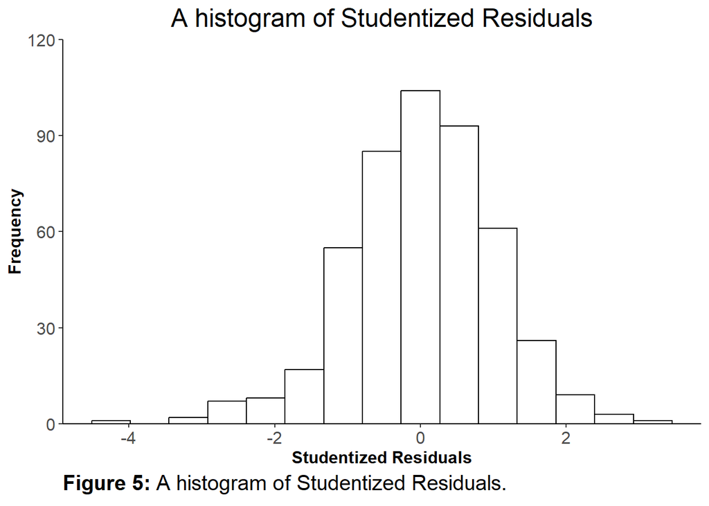

```r
# Introduce the residuals into the original dataframe
data$studentized.residuals <- rstudent(model2)

# Create a histogram of the outcome variable
plot1 <- data %>%
  ggplot(aes(x = studentized.residuals)) +
  geom_histogram(fill = "white",
                 color = "black",
                 bins = 15) +
  scale_y_continuous(expand = c(0,0), limits = c(0,120)) +
  theme_classic() +
  labs(title = "A histogram of Studentized Residuals",
       x = "Studentized Residuals",
       y = "Frequency",
       caption = bquote(bold("Figure 5:") ~ "A histogram of Studentized Residuals.")) +
  theme(plot.title = element_text(size = 18,
                                  hjust = 0.5),
        axis.title = element_text(size = 12, face = "bold"),
        axis.text = element_text(size = 12),
        plot.caption = element_text(size = 15,
                                    hjust = 0))
# Print plot 1
plot1
```

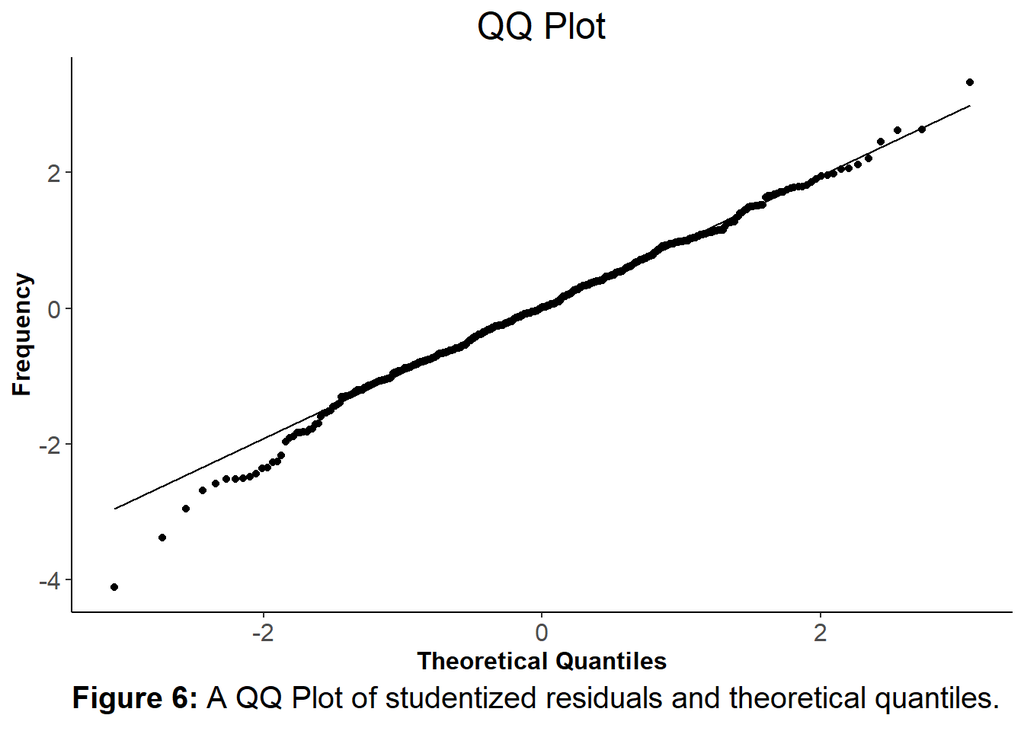

```r
# Create a QQ plot
plot2 <- data %>%
  ggplot(aes(sample= studentized.residuals)) +
  geom_qq() +
  stat_qq_line() +
  theme_classic() +
  labs(title = "QQ Plot",
       x = "Theoretical Quantiles",
       y = "Frequency",
       caption = bquote(bold("Figure 6:") ~ "A QQ Plot of studentized residuals and theoretical quantiles.")) +
  theme(plot.title = element_text(size = 18,
                                  hjust = 0.5),
        axis.title = element_text(size = 12, face = "bold"),
        axis.text = element_text(size = 12),
        plot.caption = element_text(size = 15,
                                    hjust = 0))

# Print plot 2
plot2
```

### Post-etimation techniques (homoscedasticity)

```r
library(lmtest) # bptest() function for homoscedasticity
# Run the Breusch-Pagan test
bptest(model2)
```

```
    studentized Breusch-Pagan test

data:  model2
BP = 42.661, df = 8, p-value = 0.000001017
```

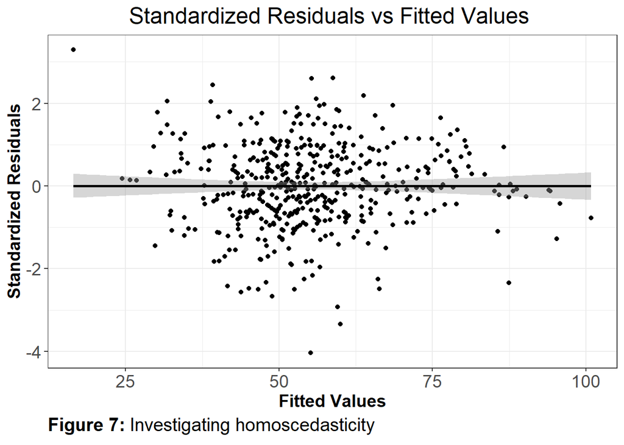

```r
# Add fitted values and standardized residuals
data$fitted.values <- model2$fitted.values
data$standardized.residuals <- rstandard(model2)

# Plot to see if there is a problem with homoscedasticity
data %>%
  ggplot(aes(x = fitted.values, y=standardized.residuals)) +
  geom_point() +
  geom_smooth(method = "lm", color = "black") +
  theme_bw() +
  labs(title = "Standardized Residuals vs Fitted Values ",
       x = "Fitted Values",
       y = "Standardized Residuals",
       caption = bquote(bold("Figure 7:") ~ "Investigating homoscedasticity")) +
  theme(plot.title = element_text(size = 18,
                                  hjust = .5),
        axis.title = element_text(size = 14, face = "bold"),
        axis.text = element_text(size = 14),
        plot.caption = element_text(size = 15,
                                    hjust = 0))
```

Because it is significant, there is heteroscedasticity.

robust standard error correction - need to figure out how to do this.

### Post-estimation techniques (independence)

Do not need to check it again if the study is cross-sectional- ours is

### Post-estimation techniques (multicolinearity)

VIF stands for variance inflation factor.